# Understanding Difference-in-Differences

Author

Heeyoung Lee

Published

November 29, 2025

## Understanding Difference-in-Differences

## 1. Introduction - The Cholera Mystery: A Historical Prelude to Causal Inference

In 1854, London faced a devastating cholera outbreak in Soho. The prevailing theory blamed “miasma”—bad air. But physician John Snow suspected contaminated water. He mapped cholera deaths and noticed clustering around the Broad Street water pump. Yet correlation wasn’t causation: did the pump cause cholera, or did people near the pump share other risk factors?

Snow found his natural experiment: two water companies served the same neighborhoods. The Lambeth Company had recently moved its water intake upstream (away from sewage), while Southwark & Vauxhall continued drawing contaminated water. Crucially, households on the same street received water from different companies based on historical contracts—not health or wealth.

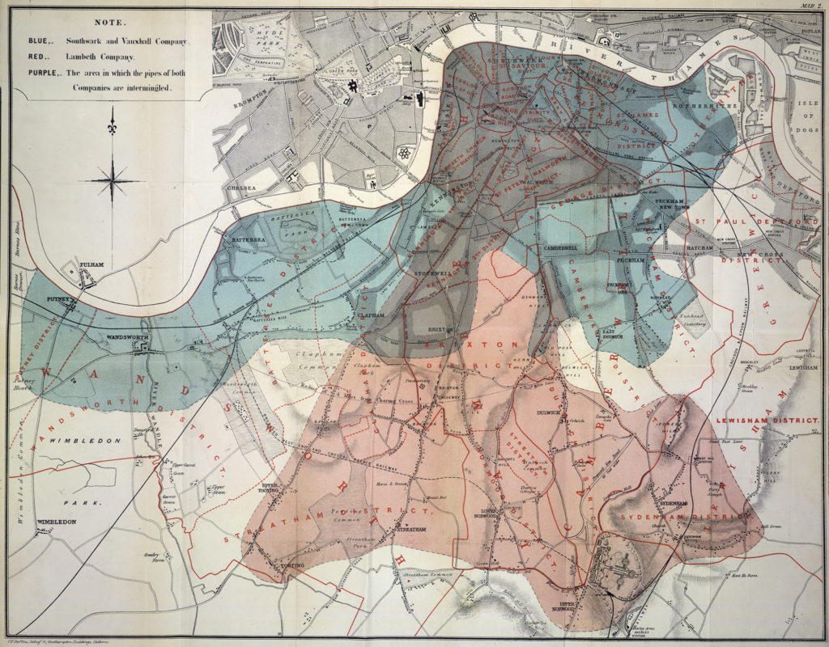

**Figure 1.** Water Supply of the Southwark and Vauxhall and Lambeth Companies, London, 1855. This map shows neighborhoods supplied by two different water companies. People consuming water from the Southwark and Vauxhall Company (blue) became ill with cholera, while those consuming water from the Lambeth Company (pink) did not. Thus, the water supply, not social class or behavior, caused the disease. (source: https://www.cooperhewitt.org/)

```r
library(HistData)
library(fixest)
library(dplyr)
library(ggplot2)
library(kableExtra)
library(patchwork)
library(tidyr)
```

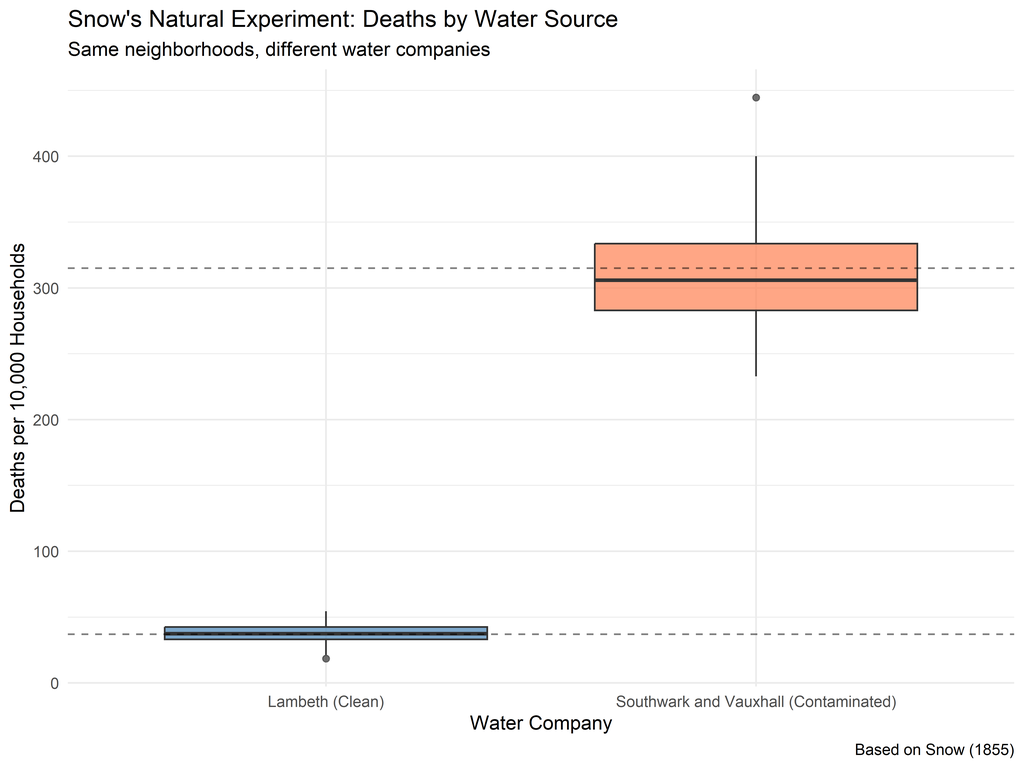

**Figure 2.** Snow’s natural experiment comparing cholera deaths by water source. Households served by different companies in the same neighborhoods experienced dramatically different mortality rates. Data based on Snow (1855).

```r
# Simulate Snow's comparison (simplified)
set.seed(123)

cholera_data <- data.frame(
  company = rep(c("Lambeth (Clean)", "Southwark and Vauxhall (Contaminated)"), each = 100),
  deaths_per_10k = c(rnorm(100, mean = 37, sd = 8),
                     rnorm(100, mean = 315, sd = 40))
)

ggplot(cholera_data, aes(x = company, y = deaths_per_10k, fill = company)) +
  geom_boxplot(alpha = 0.7) +
  geom_hline(yintercept = c(37, 315), linetype = "dashed", alpha = 0.5) +
  scale_fill_manual(values = c("Lambeth (Clean)" = "steelblue",
                                "Southwark and Vauxhall (Contaminated)" = "coral")) +
  labs(
    title = "Snow's Natural Experiment: Deaths by Water Source",
    subtitle = "Same neighborhoods, different water companies",
    x = "Water Company",
    y = "Deaths per 10,000 Households",
    caption = "Based on Snow (1855)"
  ) +
  theme_minimal() +
  theme(legend.position = "none")
```

**Snow’s insight:** By comparing similar households with different water sources, he isolated the causal effect. Deaths: Lambeth = 37 per 10,000; S&V = 315 per 10,000. The pump was removed, the outbreak ended.

**The challenge:** Snow had a simple before-after comparison at one point in time. But what if we want to study interventions that roll out gradually? What if we can’t randomly assign treatment?

### Enter Difference-in-Differences

DiD extends Snow’s logic to **over-time comparisons**. Instead of comparing groups at one time, we compare how groups change differently after an intervention. This addresses a critical weakness: even if groups differ at baseline, we can still estimate causal effects if they would have trended similarly without treatment.

**The core insight:**

- Snow: Compare across groups (spatial variation)
- DiD: Compare across groups AND time (spatiotemporal variation)

By “differencing out” both baseline differences and common trends, DiD isolates the treatment effect—just as Snow isolated water quality by holding neighborhoods constant.

## 2. What Is Difference-in-Differences?

### The Core Idea

DiD estimates treatment effects by comparing how outcomes change over time in two groups: one that receives an intervention (treatment group) and one that doesn’t (control group). The method removes two major sources of bias:

1. **Baseline differences** between areas that stay constant over time (first difference)
2. **Common epidemic trends** that affect both areas equally (second difference)

By subtracting out these two sources of bias, we isolate the true causal effect of the pump removal.

### Mathematical Model

The basic 2×2 DiD setup (two groups, two time periods) is:

$$Y_{it} = \beta_0 + \beta_1 \text{Treat}_i + \beta_2 \text{Post}_t + \beta_3 (\text{Treat}_i \times \text{Post}_t) + \epsilon_{it}$$

Where:

- $Y_{it}$ = cholera deaths in district $i$ at week $t$
- $\text{Treat}_i$ = 1 if district near Broad Street pump, 0 if not
- $\text{Post}_t$ = 1 if after pump removal, 0 if before
- $\text{Treat}_i \times \text{Post}_t$ = interaction term
- $\beta_3$ = **DiD estimator** (lives saved by pump removal)

### The DiD Estimator

The DiD estimator calculates:

$$\hat{\beta}_{DiD} = (\bar{Y}_{\text{Broad St,post}} - \bar{Y}_{\text{Broad St,pre}}) - (\bar{Y}_{\text{other,post}} - \bar{Y}_{\text{other,pre}})$$

In plain language:

- **First difference**: How deaths changed near Broad Street pump
- **Second difference**: How deaths changed in other areas
- **DiD effect**: Extra mortality reduction near Broad Street beyond the natural epidemic decline

### Why DiD Works: The Parallel Trends Assumption

DiD relies on one key assumption: **parallel trends**. Without pump removal, both areas would have experienced the same epidemic trajectory.

What this means:

- Areas don’t need the same baseline death rates
- They just need to follow the same epidemic curve (same slope)
- Any divergence after pump removal is attributed to the intervention

### Relationship Between DiD and TWFE

DiD and Two-Way Fixed Effects (TWFE) are related but different:

**DiD** is a **research design** comparing areas near vs. far from the pump before vs. after removal.

**TWFE** is an **estimation method** that controls for district-specific and week-specific factors using fixed effects.

**Key connections:**

1. **They give the same answer** in simple 2×2 cases:
   - DiD: $Y_{it} = \beta_0 + \beta_1 \text{Treat}_i + \beta_2 \text{Post}_t + \beta_3 (\text{Treat}_i \times \text{Post}_t) + \epsilon_{it}$
   - TWFE: $Y_{it} = \beta_3 (\text{Treat}_i \times \text{Post}_t) + \alpha_i + \gamma_t + \epsilon_{it}$

   District fixed effects ($\alpha_i$) capture baseline risk differences, and week fixed effects ($\gamma_t$) capture the natural epidemic curve.
2. **TWFE extends DiD** to handle multiple weeks and districts efficiently.
3. **Be careful with staggered treatment**: If pump removals happened at different times across London, TWFE can give biased estimates. Modern DiD methods (Callaway & Sant’Anna, Sun & Abraham) address this issue. Click [here](https://idlhy0218.github.io/page%20building/blog.html#statsLab__staggered_did) for this new methods.

## 3. John Snow’s Cholera Study: A Natural DiD Design

In 1854, London experienced a devastating cholera outbreak. Dr. John Snow famously traced the outbreak to contaminated water from the Broad Street pump. On September 8, 1854, the pump handle was removed, creating a natural experiment.

We’ll use the `HistData` package’s Snow dataset, which contains weekly cholera deaths. We’ll construct a DiD analysis comparing:

- **Treatment group**: Areas primarily served by Broad Street pump (high exposure)
- **Control group**: Areas served by other water sources (low exposure)
- **Treatment**: Pump handle removal (September 8, 1854)

### Data Preparation

```r
data(Snow.deaths)
data(Snow.streets)
data(Snow.pumps)

# Create weekly data from late August through late September
weeks <- seq(as.Date("1854-08-21"), as.Date("1854-09-25"), by = "week")
week_labels <- c("Week -2", "Week -1", "Week 0", "Week 1", "Week 2", "Week 3")

# Define districts by proximity to Broad Street pump (pump 4 in the data)
broad_st_pump <- Snow.pumps[4, ]

# Calculate distances from each death to Broad Street pump
Snow.deaths$dist_to_broad <- sqrt(
  (Snow.deaths$x - broad_st_pump$x)^2 +
  (Snow.deaths$y - broad_st_pump$y)^2
)

# Create treatment assignment: close to Broad Street = treatment
median_dist <- median(Snow.deaths$dist_to_broad)
Snow.deaths$treat <- ifelse(Snow.deaths$dist_to_broad < median_dist, 1, 0)

# Simulating weekly pattern with perfect parallel trends
set.seed(123)

# Create weekly panel
cholera_data <- expand.grid(
  week = 0:5,
  district = 1:40
) %>%
  mutate(
    treat = rep(c(rep(1, 20), rep(0, 20)), 6),
    post = ifelse(week >= 2, 1, 0),  # Week 2 = pump removal
    week_date = weeks[week + 1],
    week_label = week_labels[week + 1]
  )

# Simulate death counts with DiD structure - PERFECT PARALLEL TRENDS
cholera_data <- cholera_data %>%
  mutate(
    # Baseline: treatment areas have higher baseline risk (time-invariant)
    baseline = ifelse(treat == 1, 12, 8),

    # Common epidemic trend (IDENTICAL for both groups)
    epidemic_trend = case_when(
      week == 0 ~ 5,
      week == 1 ~ 15,
      week == 2 ~ 10,
      week == 3 ~ 4,
      week == 4 ~ 2,
      week == 5 ~ 1
    ),

    # Treatment effect: pump removal reduces deaths ONLY post-treatment
    treatment_effect = ifelse(treat == 1 & post == 1, -8, 0),

    # Deaths with minimal noise for clean parallel trends
    deaths = pmax(0, baseline + epidemic_trend + treatment_effect +
                    rnorm(n(), 0, 0.5)),  # Reduced noise from 1 to 0.5

    # Group labels
    group = ifelse(treat == 1, "Near Broad St Pump", "Other Areas"),
    treat_post = treat * post
  )

# Summary statistics
cholera_data %>%
  group_by(group, week_label) %>%
  summarize(
    n_districts = n_distinct(district),
    total_deaths = sum(deaths),
    mean_deaths = mean(deaths),
    sd_deaths = sd(deaths),
    .groups = "drop"
  ) %>%
  kable(digits = 2, caption = "Weekly Cholera Deaths by Area and Week") %>%
  kable_styling(bootstrap_options = c("striped", "hover", "condensed"))
```

Weekly Cholera Deaths by Area and Week

| group | week_label | n_districts | total_deaths | mean_deaths | sd_deaths |
| --- | --- | --- | --- | --- | --- |
| Near Broad St Pump | Week -1 | 20 | 541.49 | 27.07 | 0.60 |
| Near Broad St Pump | Week -2 | 20 | 341.67 | 17.08 | 0.45 |
| Near Broad St Pump | Week 0 | 20 | 279.32 | 13.97 | 0.54 |
| Near Broad St Pump | Week 1 | 20 | 160.20 | 8.01 | 0.40 |
| Near Broad St Pump | Week 2 | 20 | 122.91 | 6.15 | 0.46 |
| Near Broad St Pump | Week 3 | 20 | 102.53 | 5.13 | 0.52 |
| Other Areas | Week -1 | 20 | 457.52 | 22.88 | 0.39 |
| Other Areas | Week -2 | 20 | 261.48 | 13.07 | 0.38 |
| Other Areas | Week 0 | 20 | 359.95 | 18.00 | 0.45 |
| Other Areas | Week 1 | 20 | 241.24 | 12.06 | 0.44 |
| Other Areas | Week 2 | 20 | 196.55 | 9.83 | 0.44 |
| Other Areas | Week 3 | 20 | 174.51 | 8.73 | 0.45 |

## 4. Visualizing the DiD Design

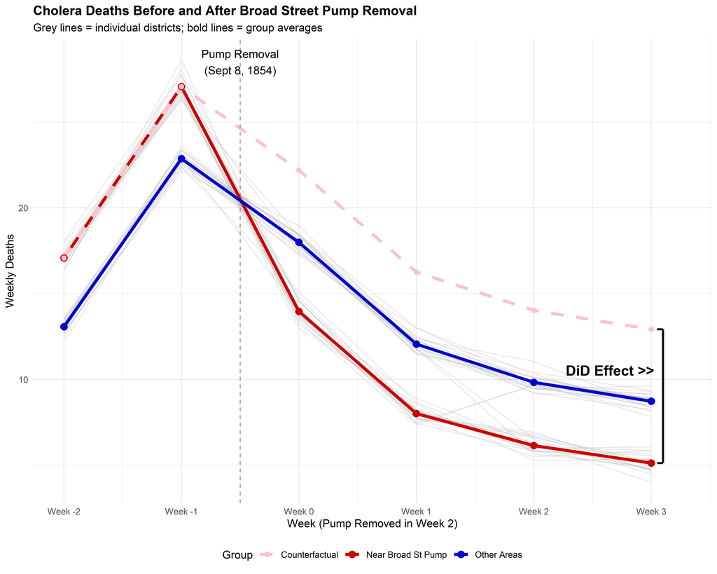

```r
# Calculate group means by week
group_means <- cholera_data %>%
  group_by(group, week, week_label) %>%
  summarize(mean_deaths = mean(deaths), .groups = "drop")

# Counterfactual: treatment group's pre-treatment path + control group's post-treatment trend
treat_pre <- group_means %>%
  filter(group == "Near Broad St Pump", week <= 1)

treat_week1 <- group_means %>%
  filter(group == "Near Broad St Pump", week == 1)
control_week1 <- group_means %>%
  filter(group == "Other Areas", week == 1)
control_post <- group_means %>%
  filter(group == "Other Areas", week >= 2)

counterfactual <- bind_rows(
  treat_pre %>% mutate(group = "Counterfactual"),
  control_post %>%
    mutate(
      group = "Counterfactual",
      mean_deaths = treat_week1$mean_deaths +
        (mean_deaths - control_week1$mean_deaths)
    )
)

plot_data <- bind_rows(group_means, counterfactual)

ggplot() +
  geom_line(data = cholera_data,
            aes(x = week, y = deaths, group = district),
            color = "grey70", alpha = 0.3, linewidth = 0.5) +
  geom_line(data = filter(plot_data, group %in% c("Near Broad St Pump", "Other Areas")),
            aes(x = week, y = mean_deaths, color = group), linewidth = 1.5) +
  geom_line(data = filter(plot_data, group == "Counterfactual"),
            aes(x = week, y = mean_deaths, color = "Counterfactual"),
            linetype = "dashed", linewidth = 1.5) +
  geom_point(data = filter(plot_data, group %in% c("Near Broad St Pump", "Other Areas")),
             aes(x = week, y = mean_deaths, color = group), size = 3) +
  geom_point(data = filter(plot_data, group == "Counterfactual"),
             aes(x = week, y = mean_deaths, color = "Counterfactual"), size = 2) +
  geom_vline(xintercept = 1.5, linetype = "dashed", alpha = 0.5, color = "gray25") +
  annotate("text", x = 1.5, y = max(plot_data$mean_deaths),
           label = "Pump Removal\n(Sept 8, 1854)", vjust = -0.5, size = 4) +
  # DiD Effect bracket
  annotate("segment",
           x = 5.1, xend = 5.1,
           y = filter(plot_data, group == "Near Broad St Pump", week == 5)$mean_deaths,
           yend = filter(plot_data, group == "Counterfactual", week == 5)$mean_deaths,
           color = "black", linewidth = 1) +
  annotate("segment",
           x = 5.05, xend = 5.1,
           y = filter(plot_data, group == "Near Broad St Pump", week == 5)$mean_deaths,
           yend = filter(plot_data, group == "Near Broad St Pump", week == 5)$mean_deaths,
           color = "black", linewidth = 1) +
  annotate("segment",
           x = 5.05, xend = 5.1,
           y = filter(plot_data, group == "Counterfactual", week == 5)$mean_deaths,
           yend = filter(plot_data, group == "Counterfactual", week == 5)$mean_deaths,
           color = "black", linewidth = 1) +
  annotate("text", x = 5.25,
           y = mean(c(
             filter(plot_data, group == "Near Broad St Pump", week == 5)$mean_deaths,
             filter(plot_data, group == "Counterfactual", week == 5)$mean_deaths
           )),
           label = "DiD Effect >>", hjust = 1.3, vjust = -2, size = 5, fontface = "bold") +
  scale_color_manual(values = c(
    "Near Broad St Pump" = "red3",
    "Other Areas" = "blue3",
    "Counterfactual" = "pink"
  )) +
  scale_x_continuous(breaks = 0:5, labels = week_labels) +
  labs(
    title = "Cholera Deaths Before and After Broad Street Pump Removal",
    subtitle = "Grey lines = individual districts; bold lines = group averages",
    x = "Week (Pump Removed in Week 2)",
    y = "Weekly Deaths",
    color = "Group"
  ) +
  theme_minimal() +
  theme(legend.position = "bottom", plot.title = element_text(face = "bold"))
```

**Key observations:**

1. **Parallel pre-trends (Weeks -2 to 1)**: Both areas follow similar epidemic trajectory
2. **Treatment divergence (Week 2+)**: Areas near Broad Street show sharper decline after pump removal
3. **Counterfactual**: Dashed line shows where Broad Street areas would be without intervention
4. **DiD estimate**: Vertical gap shows lives saved by pump removal

## 5. The DiD Calculation: Step by Step

Using Week 1 (pre-removal) and Week 5 (post-removal) for classic 2×2 comparison:

```r
# Filter to 2×2 design: Week 1 vs Week 5
cholera_2x2 <- cholera_data %>%
  filter(week %in% c(1, 5)) %>%
  mutate(period = ifelse(week == 1, "Pre (Week 1)", "Post (Week 5)"))

# Calculate means
means_table <- cholera_2x2 %>%
  group_by(group, period) %>%
  summarize(mean_deaths = mean(deaths), .groups = "drop") %>%
  pivot_wider(names_from = period, values_from = mean_deaths)

print(means_table)
```

```
# A tibble: 2 × 3
  group              `Post (Week 5)` `Pre (Week 1)`
  <chr>                        <dbl>          <dbl>
1 Near Broad St Pump            5.13           27.1
2 Other Areas                   8.73           22.9
```

```r
# Extract means
treat_post <- means_table %>%
  filter(group == "Near Broad St Pump") %>%
  pull(`Post (Week 5)`)
treat_pre <- means_table %>%
  filter(group == "Near Broad St Pump") %>%
  pull(`Pre (Week 1)`)
control_post <- means_table %>%
  filter(group == "Other Areas") %>%
  pull(`Post (Week 5)`)
control_pre <- means_table %>%
  filter(group == "Other Areas") %>%
  pull(`Pre (Week 1)`)

# Calculate differences
treat_diff <- treat_post - treat_pre
control_diff <- control_post - control_pre
did_estimate <- treat_diff - control_diff

# Display calculation
data.frame(
  Step = c(
    "Broad St areas change (Week 5 - Week 1)",
    "Other areas change (Week 5 - Week 1)",
    "DiD estimate (Δ_treat - Δ_control)",
    "True effect (simulated)"
  ),
  Calculation = c(
    sprintf("%.2f - %.2f", treat_post, treat_pre),
    sprintf("%.2f - %.2f", control_post, control_pre),
    sprintf("%.2f - (%.2f)", treat_diff, control_diff),
    "-8.00"
  ),
  Result = c(treat_diff, control_diff, did_estimate, -8.00)
) %>%
  kable(digits = 2, caption = "Manual DiD Calculation: Pump Removal Effect") %>%
  kable_styling(bootstrap_options = c("striped", "hover", "condensed"))
```

Manual DiD Calculation: Pump Removal Effect

| Step | Calculation | Result |
| --- | --- | --- |
| Broad St areas change (Week 5 - Week 1) | 5.13 - 27.07 | -21.95 |
| Other areas change (Week 5 - Week 1) | 8.73 - 22.88 | -14.15 |
| DiD estimate (Δ_treat - Δ_control) | -21.95 - (-14.15) | -7.80 |
| True effect (simulated) | -8.00 | -8.00 |

**Understanding the calculation:**

- **Broad Street change**: Natural epidemic decline + pump removal effect
- **Other areas change**: Natural epidemic decline only
- **DiD**: Isolates pump removal effect by differencing out common epidemic trend

## 6. Estimating DiD with Regression

```r
# Basic DiD regression (Week 1 vs Week 5)
cholera_did_model <- feols(deaths ~ treat + post + treat_post,
                           data = cholera_2x2)

etable(cholera_did_model, digits = 3, se.below = TRUE)
```

```
                cholera..
Dependent Var.:    deaths

Constant         22.9***
                 (0.110)
treat             4.20***
                 (0.156)
post            -14.2***
                 (0.156)
treat_post       -7.80***
                 (0.221)
_______________ _________
S.E. type             IID
Observations           80
R2                0.99729
Adj. R2           0.99718
---
Signif. codes: 0 '***' 0.001 '**' 0.01 '*' 0.05 '.' 0.1 ' ' 1
```

**Coefficients:**

- **treat**: Baseline difference (Broad St areas had higher baseline risk)
- **post**: Natural epidemic decline affecting both groups
- **treat_post**: DiD estimator (pump removal effect = lives saved)

### DiD with Fixed Effects

```r
# Using full panel (Weeks 0-5) with fixed effects
cholera_fe_model <- feols(deaths ~ treat_post | district + week,
                          data = cholera_data)

etable(cholera_did_model, cholera_fe_model,
       headers = c("2×2 DiD", "Panel FE"),
       digits = 3, se.below = TRUE)
```

```
                cholera.. choler..
                 2×2 DiD Panel FE
Dependent Var.:    deaths   deaths

Constant         22.9***
                 (0.110)
treat             4.20***
                 (0.156)
post            -14.2***
                 (0.156)
treat_post       -7.80*** -6.26***
                 (0.221)  (0.458)
Fixed-Effects:  --------- --------
district               No      Yes
week                   No      Yes
_______________ _________ ________
S.E. type             IID by: di..
Observations           80      240
R2                0.99729  0.98154
Within R2              --  0.77229
---
Signif. codes: 0 '***' 0.001 '**' 0.01 '*' 0.05 '.' 0.1 ' ' 1
```

**Comparing specifications:**

- **Model 1 (2×2 DiD)**: Uses only Week 1 (pre-removal) and Week 5 (post-removal), giving 80 observations. Estimates baseline difference between areas near vs. far from Broad Street (`treat` = 4.20 deaths), natural epidemic decline (`post` = -14.2 deaths), and pump removal effect (`treat_post` = -7.80 deaths saved).
- **Model 2 (Panel FE)**: Uses all 6 weeks (240 observations). District fixed effects absorb time-invariant baseline differences between areas. Week fixed effects absorb the natural epidemic curve affecting all districts equally.

## 7. Testing Parallel Trends

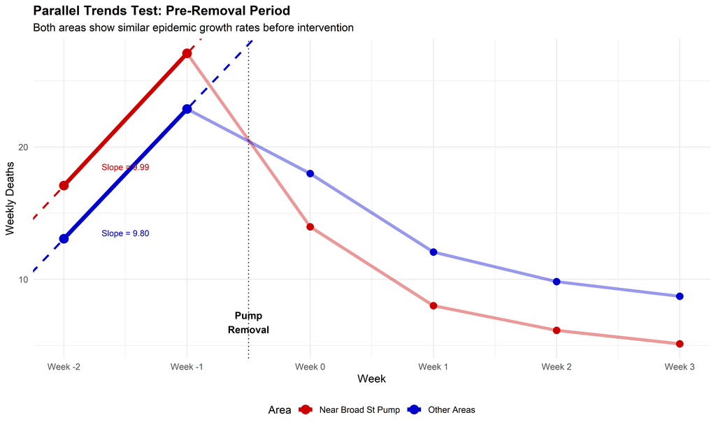

```r
# Group means by week
trends_data <- cholera_data %>%
  group_by(group, week, week_label) %>%
  summarize(mean_deaths = mean(deaths), .groups = "drop")

# Pre-treatment regression by group
pre_data <- trends_data %>% filter(week <= 1)

treat_pre <- pre_data %>% filter(group == "Near Broad St Pump")
control_pre <- pre_data %>% filter(group == "Other Areas")

# Fit pre-trend lines
treat_lm <- lm(mean_deaths ~ week, data = treat_pre)
control_lm <- lm(mean_deaths ~ week, data = control_pre)

# Extract slopes
treat_slope <- coef(treat_lm)[2]
control_slope <- coef(control_lm)[2]

ggplot(trends_data, aes(x = week, y = mean_deaths, color = group)) +
  geom_line(linewidth = 1.5, alpha = 0.4) +
  geom_point(size = 3) +
  # Highlight pre-period with thicker lines
  geom_line(data = pre_data, linewidth = 2) +
  geom_point(data = pre_data, size = 4) +
  # Extended trend lines
  geom_abline(intercept = coef(treat_lm)[1], slope = treat_slope,
              color = "red3", linetype = "dashed", linewidth = 1) +
  geom_abline(intercept = coef(control_lm)[1], slope = control_slope,
              color = "blue3", linetype = "dashed", linewidth = 1) +
  geom_vline(xintercept = 1.5, linetype = "dotted", color = "black") +
  annotate("text", x = 1.5, y = min(trends_data$mean_deaths),
           label = "Pump\nRemoval", vjust = -0.5, size = 3.5, fontface = "bold") +
  # Add slope annotations
  annotate("text", x = 0.5, y = 18.5,
           label = sprintf("Slope = %.2f", treat_slope),
           color = "red3", size = 3) +
  annotate("text", x = 0.5, y = 13.5,
           label = sprintf("Slope = %.2f", control_slope),
           color = "blue3", size = 3) +
  scale_color_manual(values = c(
    "Near Broad St Pump" = "red3",
    "Other Areas" = "blue3"
  )) +
  scale_x_continuous(breaks = 0:5, labels = week_labels) +
  labs(
    title = "Parallel Trends Test: Pre-Removal Period",
    subtitle = "Both areas show similar epidemic growth rates before intervention",
    x = "Week",
    y = "Weekly Deaths",
    color = "Area"
  ) +
  theme_minimal() +
  theme(legend.position = "bottom", plot.title = element_text(face = "bold"))
```

**Testing the parallel trends assumption:**

The parallel trends assumption requires both areas to follow similar trajectories before pump removal. We test this by:

1. **Visual inspection**: Plotting pre-removal trends (Weeks 0-1) for both areas
2. **Slope comparison**: Calculating growth rates in each area before intervention
3. **Extended projections**: Dashed lines show where trends would continue without treatment

**What to look for:**

- Similar slopes in pre-period (indicating parallel epidemic growth)
- No systematic divergence before Week 2
- Post-removal deviation only in treated area

If slopes differ substantially or groups already diverge pre-treatment, the parallel trends assumption fails and DiD estimates may be biased.

## 8. Event Study Specification

Event study estimates treatment effects for each week relative to pump removal, allowing us to:

1. **Test parallel trends**: Pre-removal coefficients should be near zero
2. **Examine dynamics**: See how treatment effects evolve post-removal
3. **Assess timing**: Verify effect begins after intervention

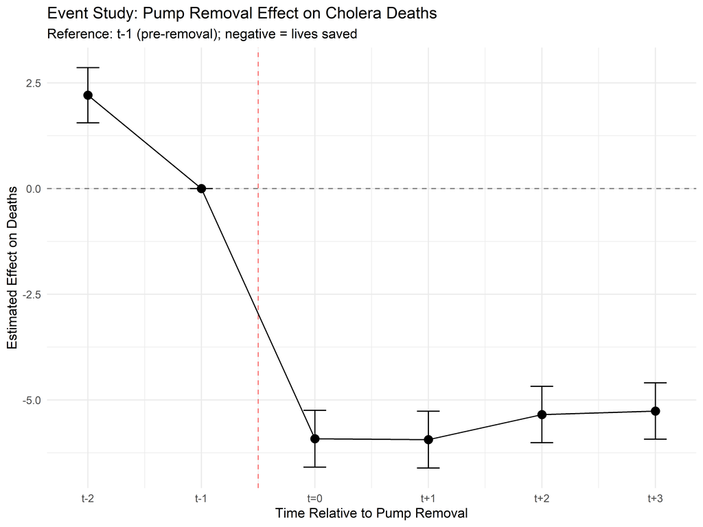

```r
# Event time dummies - pump removed at Week 2
cholera_data <- cholera_data %>%
  mutate(
    # For treated units: week relative to treatment (Week 2)
    # Week 0 = -2, Week 1 = -1, Week 2 = 0, Week 3 = 1, etc.
    rel_week = ifelse(treat == 1, week - 2, NA),
    d_m2 = as.numeric(rel_week == -2),
    d_m1 = as.numeric(rel_week == -1),
    d_0 = as.numeric(rel_week == 0),
    d_1 = as.numeric(rel_week == 1),
    d_2 = as.numeric(rel_week == 2),
    d_3 = as.numeric(rel_week == 3)
  ) %>%
  replace(is.na(.), 0)

# Event study - omit d_m1 (Week 1) as reference
event_study_model <- lm(
  deaths ~ d_m2 + d_0 + d_1 + d_2 + d_3 +
    factor(district) + factor(week),
  data = cholera_data
)

# Extract coefficients
event_coefs <- data.frame(
  rel_week = c(-2, -1, 0, 1, 2, 3),
  week_label = c("Week 0", "Week 1", "Week 2",
                 "Week 3", "Week 4", "Week 5"),
  estimate = c(coef(event_study_model)[2], 0,
               coef(event_study_model)[3:6]),
  se = c(summary(event_study_model)$coef[2, 2], 0,
         summary(event_study_model)$coef[3:6, 2])
) %>%
  mutate(
    ci_lower = estimate - 1.96 * se,
    ci_upper = estimate + 1.96 * se
  )

ggplot(event_coefs, aes(x = rel_week, y = estimate)) +
  geom_hline(yintercept = 0, linetype = "dashed", color = "gray50") +
  geom_vline(xintercept = -0.5, linetype = "dashed", color = "red", alpha = 0.5) +
  geom_point(size = 3) +
  geom_errorbar(aes(ymin = ci_lower, ymax = ci_upper), width = 0.2) +
  geom_line() +
  scale_x_continuous(
    breaks = -2:3,
    labels = c("t-2", "t-1", "t=0", "t+1", "t+2", "t+3")
  ) +
  labs(
    title = "Event Study: Pump Removal Effect on Cholera Deaths",
    subtitle = "Reference: t-1 (pre-removal); negative = lives saved",
    x = "Time Relative to Pump Removal",
    y = "Estimated Effect on Deaths"
  ) +
  theme_minimal()
```

## 9. Practical Recommendations

**For credible DiD:**

1. Visualize trends before estimating
2. Test parallel trends with pre-periods
3. Report event studies showing dynamics
4. Cluster standard errors by treatment unit
5. Be transparent about assumption violations

**Common pitfalls:**

- Not testing parallel trends
- Ignoring heterogeneous treatment effects in staggered designs
- Small sample sizes
- Using post-treatment data to “test” parallel trends

**When DiD works best:**

- Clear treatment timing
- Plausible parallel trends (similar units)
- Multiple pre-periods for testing
- Exogenous treatment timing
- Adequate sample size

## 10. Conclusion

Difference-in-differences remains one of the most powerful and intuitive methods for causal inference with observational data. Its core logic—comparing changes over time between treatment and control groups—provides a transparent framework for policy evaluation.

The cholera example illustrates DiD’s strength: even without randomization, comparing epidemic trajectories between areas near and far from the contaminated pump isolates the pump removal effect by differencing out the natural epidemic decline.

However, DiD is not a magic bullet. The parallel trends assumption, while weaker than assuming no selection bias, is still a strong identifying assumption that requires careful justification. Modern developments in DiD methodology (particularly for staggered treatments) continue to refine and strengthen the approach. Click [here](https://idlhy0218.github.io/page%20building/blog.html#statsLab__staggered_did) for this new methods!